# Vulnerability to Covid-19 in Scotland

Analysis by NHS Health Board

David Henderson

30/03/2020

# Introduction

Code to accompany blog post on personal and SCADR pages.

## Packages

Load in required packages

```r
library(tidyverse)
library(ggrepel)
library(ggthemes)
library(janitor)
library(gtools)
library(sf)
library(cowplot)

theme_set(theme_minimal(base_family = "Roboto",
                        base_size = 18) +
            theme(panel.grid.minor = element_blank(),
                  plot.margin = margin(3,15,3,3,"mm")))
options(scipen = 10)
```

## Data

Measurement data comes from [NHS Scotland’s open data pages](https://www.opendata.nhs.scot/theme/isd). I use the most recent prescribing data available from [Dec 2019](https://www.opendata.nhs.scot/dataset/prescriptions-in-the-community/resource/fa276ad2-669a-472f-9c47-809f199fae21). The geography lookup codes were derived from the [datazone 2011 file](https://www.opendata.nhs.scot/dataset/geography-codes-and-labels/resource/395476ab-0720-4740-be07-ff4467141352) (although in hindsight I could have just as easily used the [Health Board lookup](https://www.opendata.nhs.scot/dataset/geography-codes-and-labels/resource/652ff726-e676-4a20-abda-435b98dd7bdc)]). Population estimates for each health board were derived from [this file](https://www.opendata.nhs.scot/dataset/population-estimates/resource/27a72cc8-d6d8-430c-8b4f-3109a9ceadb1) using the most recent estimates from 2018.

Some of these files only need some very quick cleaning to either drop unnecessary information or quick calculations so do those in this chunk of code where appropriate.

*Note:* the first of these files is very large and can take a few minutes to load.

```r
#Load in prescribing data direct from source. This is a very large file
#so using data.table's fread() function

presc <- data.table::fread("https://www.opendata.nhs.scot/dataset/84393984-14e9-4b0d-a797-b288db64d088/resource/fa276ad2-669a-472f-9c47-809f199fae21/download/pitc201912.csv")

#Load in Health Board lookup file to match HB codes to names
#Some wuick tidying here to drop unnecessary data in this file
geog <- data.table::fread("https://www.opendata.nhs.scot/dataset/9f942fdb-e59e-44f5-b534-d6e17229cc7b/resource/395476ab-0720-4740-be07-ff4467141352/download/geography_codes_and_labels_dz2011_10012020.csv") %>%
  clean_names %>%
  select(hb2014, hb2014name) %>%
  distinct(hb2014, hb2014name)

#Load in popuoation estimates
#More quick cleaning - keep most recent year of data and drop data
#For Scotland as a whole
pop <- data.table::fread("https://www.opendata.nhs.scot/dataset/7f010430-6ce1-4813-b25c-f7f335bdc4dc/resource/27a72cc8-d6d8-430c-8b4f-3109a9ceadb1/download/hb2014_pop_est_01072019.csv") %>%
  mutate(Year = as.character(Year)) %>%
  filter(Year == "2018" & HB2014 != "S92000003")

#Quickly calculate population for each health board.
hb_pop <-
  pop %>%
  select(HB2014, AllAges) %>%
  group_by(HB2014) %>%
  summarise(total_pop = sum(AllAges)) %>%
  clean_names
```

# Tidy the prescribing data

Here what the prescribing file looks like

```r
presc
```

| HBT | GPPractice | BNFItemCode | BNFItemDescription | ClassOfPreparationCode | NumberOfPaidItems | PaidQuantity | GrossIngredientCost | PaidDateMonth |
| --- | --- | --- | --- | --- | --- | --- | --- | --- |
| S08000015 | 80005 |  |  | G | 43 | 3405.0 | 887.60 | 201912 |
| S08000015 | 80005 |  |  | P | 4 | 440.0 | 79.39 | 201912 |
| S08000015 | 80005 | 0101021B0BEADAJ | GAVISCON INFANT_ORAL PDR SACH | P | 7 | 555.0 | 101.22 | 201912 |
| S08000015 | 80005 | 0101021B0BEAIAL | GAVISCON ADVANCE_LIQ (ANISEED) S/F | P | 6 | 3700.0 | 48.88 | 201912 |
| S08000015 | 80005 | 0101021B0BEAQAP | GAVISCON ADVANCE_TAB CHBLE 500MG MINT | G | 1 | 30.0 | 1.54 | 201912 |
| S08000015 | 80005 | 0101021B0BEAQAP | GAVISCON ADVANCE_TAB CHBLE 500MG MINT | P | 2 | 160.0 | 8.19 | 201912 |
| S08000015 | 80005 | 0101021B0BEBEAL | GAVISCON ADVANCE_LIQ (PEPPERMINT) S/F | G | 1 | 500.0 | 5.12 | 201912 |
| S08000015 | 80005 | 0101021B0BEBEAL | GAVISCON ADVANCE_LIQ (PEPPERMINT) S/F | P | 6 | 2550.0 | 28.86 | 201912 |
| S08000015 | 80005 | 0101021B0BIAAAH | PEPTAC_LIQ (ANISEED) S/F | P | 31 | 17000.0 | 66.30 | 201912 |
| S08000015 | 80005 | 0101021B0BIABAH | PEPTAC_LIQ (PEPPERMINT) S/F | P | 27 | 15500.0 | 60.45 | 201912 |

[output cut: 9990 more lines]

I want a measure to reflect the vulnerability in each health board area. Respiratory diseases have been shown in early studies to be *one* of the indicators of people developing more severe Covid-19 related. complications.

In order to do that, I subset the prescribing data to include only medicines from chapter 3 of the British National Formulary (BNF) (`BNFItemCode`) which lists drugs for the respiratory system. Then join in the health board names (to match the codes), and the population estimate for each health board.

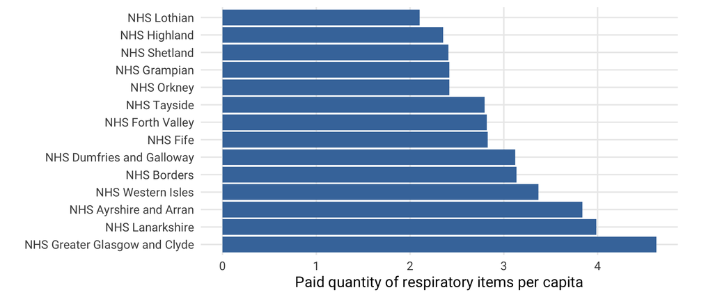

```r
presc_resp <-
  presc %>%
  #names to lower case
  clean_names %>%
  #tidy up the HB name
  rename(hb2014 = hbt) %>%
  #Keep only rows from chapter 3
  filter(str_detect(bnf_item_code, "^03")) %>%
  #Join in the HB lookup
  left_join(., geog) %>%
  #Join in the population estimate
  left_join(., hb_pop) %>%
  #group
  group_by(hb2014) %>%
  #total paid items and divide by population
  mutate(resp = sum(paid_quantity)/total_pop) %>%
  #Just keep first line for each HB - actual presc not required
  #now as we have summary measures.
  distinct(hb2014, resp, .keep_all = TRUE) %>%
  #keep only required columns
  select(hb2014, hb2014name, resp, total_pop)

#Plot the result
presc_resp %>%
  ggplot(aes(reorder(hb2014name, -resp), resp)) +
  geom_col(fill = "#4477AA") +
  coord_flip() +
  labs(x = "",
       y = "Paid quantity of respiratory items per capita")
```

#Tidy population data

Here I go back to the raw population data (`pop`) to calculate the proportion of the population over the age of 70 in each health board area and join it to the cleaned prescribing data from the section above. This is assigned to a new object `final_tab`.

```r
final_tab <-
  pop %>%
  #select rows from 70 plus only
  select(HB2014, Age70:Age90plus) %>%
  #calculate total population over 70 in a new column
  mutate(pop_70plus = rowSums(.[2:22])) %>%
  #drop all the other age columns
  select(HB2014, pop_70plus) %>%
  #column names to lower case
  clean_names %>%
  #join to the cleaned prescribing data
  left_join(presc_resp, .) %>%
  #Drop the additional row for each HB
  distinct(hb2014name, .keep_all = TRUE) %>%
  #Calculate % over 70 in a new column and drop the "NHS" prefix
  #from the HB name
  mutate(pct70 = round(pop_70plus/total_pop * 100,1),
         hb2014name = str_replace_all(hb2014name, "NHS ", "")) %>%
  #drop the grouping
  ungroup

final_tab
```

| hb2014 | hb2014name | resp | total_pop | pop_70plus | pct70 |
| --- | --- | --- | --- | --- | --- |
| S08000015 | Ayrshire and Arran | 3.836414 | 369670 | 32930 | 8.9 |
| S08000016 | Borders | 3.135196 | 115270 | 10961 | 9.5 |
| S08000017 | Dumfries and Galloway | 3.121742 | 148790 | 14734 | 9.9 |
| S08000019 | Forth Valley | 2.817313 | 306070 | 22899 | 7.5 |
| S08000020 | Grampian | 2.418154 | 584550 | 41366 | 7.1 |
| S08000022 | Highland | 2.351976 | 321800 | 28823 | 9.0 |
| S08000024 | Lothian | 2.100564 | 897770 | 58984 | 6.6 |
| S08000025 | Orkney | 2.418251 | 22190 | 1989 | 9.0 |
| S08000026 | Shetland | 2.410222 | 22990 | 1672 | 7.3 |
| S08000028 | Western Isles | 3.368580 | 26830 | 2743 | 10.2 |

[output cut: 4 more lines]

I can now plot the % of the population over 70 against the paid quantity of prescribed items per capita

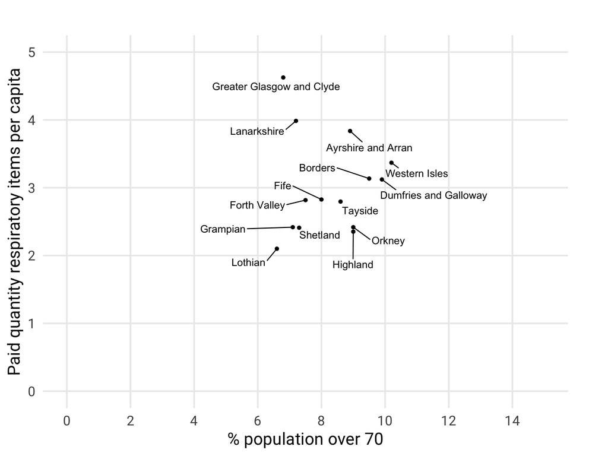

```r
final_tab %>%
  ggplot(aes(pct70, resp)) +
  geom_point() +
  geom_text_repel(aes(label = hb2014name), force = 20) +
  scale_x_continuous(limits = c(0, 15),
                     breaks = scales::pretty_breaks(n = 6)) +
  scale_y_continuous(limits = c(0, 5),
                     breaks = scales::pretty_breaks(n = 6)) +
  labs(title = "",
       x = "% population over 70",
       y = "Paid quantity respiratory items per capita")
```

#Create tertiles

Here I create tertiles for each measure and assign each health board to one of 9 possible category’s depending on values of % over 70 and paid quantity of respiratory items

```r
#generate tertiles
final_tab$age70tert <- quantcut(final_tab$pct70, q=3, labels=FALSE)
final_tab$resptert <- quantcut(final_tab$resp, q=3, labels=FALSE)

#save cutoffs
pct70_1 <- quantile(final_tab$pct70, probs=1/3, na.rm=TRUE)
pct70_2 <- quantile(final_tab$pct70, probs=2/3, na.rm=TRUE)
resp_1 <- quantile(final_tab$resp, probs=1/3, na.rm=TRUE)
resp_2 <- quantile(final_tab$resp, probs=2/3, na.rm=TRUE)

#generate 9-category index for map key
final_tab$key <- case_when(
  final_tab$age70tert==1 & final_tab$resptert==1 ~ 1,
  final_tab$age70tert==1 & final_tab$resptert==2 ~ 2,
  final_tab$age70tert==1 & final_tab$resptert==3 ~ 3,
  final_tab$age70tert==2 & final_tab$resptert==1 ~ 4,
  final_tab$age70tert==2 & final_tab$resptert==2 ~ 5,
  final_tab$age70tert==2 & final_tab$resptert==3 ~ 6,
  final_tab$age70tert==3 & final_tab$resptert==1 ~ 7,
  final_tab$age70tert==3 & final_tab$resptert==2 ~ 8,
  final_tab$age70tert==3 & final_tab$resptert==3 ~ 9
)

#fill in corresponding colours
final_tab$colour <- case_when(
  final_tab$key==1 ~ "#CABED0",
  final_tab$key==2 ~ "#BC7C5F",
  final_tab$key==3 ~ "#AE3A4E",
  final_tab$key==4 ~ "#89A1C8",
  final_tab$key==5 ~ "#806A8A",
  final_tab$key==6 ~ "#77324C",
  final_tab$key==7 ~ "#4885C1",
  final_tab$key==8 ~ "#435786",
  final_tab$key==9 ~ "#3f2949"

)

keydata <-
  final_tab %>%
  filter(!is.na(colour)) %>%
  group_by(age70tert, resptert) %>%
  summarise(RGB=unique(colour)) %>%
  ungroup %>%
  #14 HBs fit into 7 (not 9 groups) need to add in the
  #Unused groups manually
  add_row(., age70tert = 1, resptert = 2, RGB = "#BC7C5F") %>%
  add_row(., age70tert = 2, resptert = 1, RGB = "#89A1C8")

final_tab
```

| hb2014 | hb2014name | resp | total_pop | pop_70plus | pct70 | age70tert | resptert | key | colour |
| --- | --- | --- | --- | --- | --- | --- | --- | --- | --- |
| S08000015 | Ayrshire and Arran | 3.836414 | 369670 | 32930 | 8.9 | 2 | 3 | 6 | #77324C |
| S08000016 | Borders | 3.135196 | 115270 | 10961 | 9.5 | 3 | 3 | 9 | #3f2949 |
| S08000017 | Dumfries and Galloway | 3.121742 | 148790 | 14734 | 9.9 | 3 | 2 | 8 | #435786 |
| S08000019 | Forth Valley | 2.817313 | 306070 | 22899 | 7.5 | 2 | 2 | 5 | #806A8A |
| S08000020 | Grampian | 2.418154 | 584550 | 41366 | 7.1 | 1 | 1 | 1 | #CABED0 |
| S08000022 | Highland | 2.351976 | 321800 | 28823 | 9.0 | 3 | 1 | 7 | #4885C1 |
| S08000024 | Lothian | 2.100564 | 897770 | 58984 | 6.6 | 1 | 1 | 1 | #CABED0 |
| S08000025 | Orkney | 2.418251 | 22190 | 1989 | 9.0 | 3 | 1 | 7 | #4885C1 |
| S08000026 | Shetland | 2.410222 | 22990 | 1672 | 7.3 | 1 | 1 | 1 | #CABED0 |
| S08000028 | Western Isles | 3.368580 | 26830 | 2743 | 10.2 | 3 | 3 | 9 | #3f2949 |

[output cut: 4 more lines]

#Plot the map

##Shapefile

First of all I need to read in the shapefile. As these are usually zipped I have downloaded it into the “data” folder in this project and read it in from there.

The source data comes from [data.gov.uk](https://data.gov.uk/dataset/27d0fe5f-79bb-4116-aec9-a8e565ff756a/nhs-health-boards)

```r
#read in the shape file and change name to match final_tab name
hb_shp <- read_sf("data/SG_NHS_HealthBoards_2019/SG_NHS_HealthBoards_2019.shp") %>%
  rename(hb2014name = HBName)

#join to the analysis data frame
final_tab <-
  final_tab %>%
  left_join(., hb_shp)
```

## Main Plot

Now I can plot. Using the `dplyr` join syntax means the data is now a `tbl` which means I need to specify the geometry in the `geom_sf()` call.

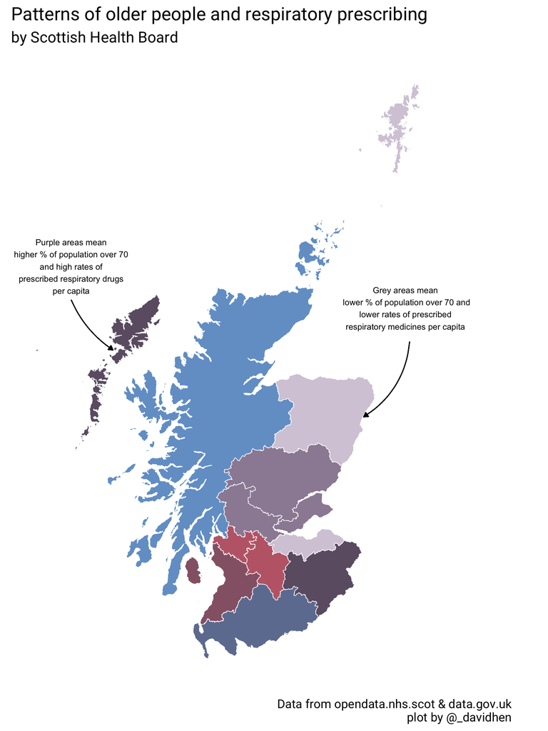

```r
map <-
  ggplot(final_tab) +
  geom_sf(aes(geometry = geometry,
              fill = colour),
          alpha = 0.8,
          colour = 'white',
          size = 0.3) +
  scale_fill_identity() +
  annotate("text", x=50000, y=1000000, label="Purple areas mean\nhigher % of population over 70\nand high rates of\nprescribed respiratory drugs\nper capita", size=3.5) +
  annotate("text", x = 450000, y=950000, label= "Grey areas mean\n lower % of population over 70 and\nlower rates of prescribed\nrespiratory medicines per capita", size = 3.5) +
  geom_curve(aes(x=50000, y=960000, xend=100000, yend=900000),
             curvature=0.15,
             arrow = arrow(angle = 30, type = "closed", length = unit(2, "mm"))) +
  geom_curve(aes(x=455000, y=910000, xend=400000, yend=820000),
             curvature=-0.25,
             arrow = arrow(angle = 30, type = "closed", length = unit(2, "mm")))+
  expand_limits(x = 550000) +
  labs(title="Patterns of older people and respiratory prescribing",
       subtitle="by Scottish Health Board",
       caption="Data from opendata.nhs.scot & data.gov.uk\nplot by @_davidhen") +
  theme(axis.line=element_blank(),
        axis.ticks=element_blank(),
        axis.text=element_blank(),
        axis.title=element_blank(),
        panel.grid = element_blank())
map
```

## Plot key

Now create the key

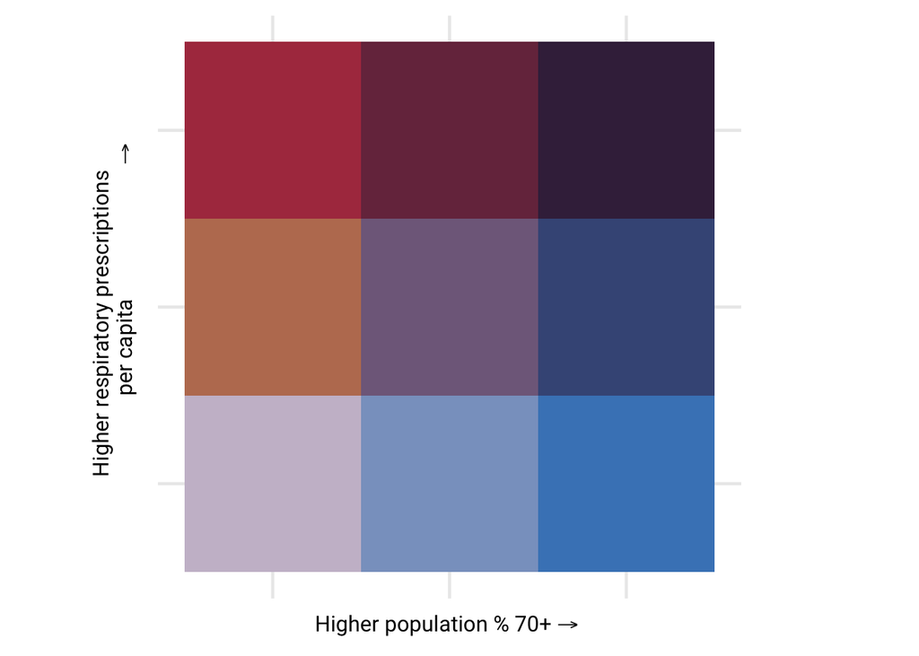

```r
key <- ggplot(keydata)+
  geom_tile(aes(x=age70tert, y=resptert, fill=RGB))+
  scale_fill_identity()+
  labs(x = expression("Higher population % 70+" %->%  ""),
       y = expression("Higher respiratory prescriptions\n               per capita" %->%  "")) +
  # make font small enough
  theme(
    axis.title = element_text(size = 12),
    axis.line=element_blank(),
    axis.ticks=element_blank(),
    axis.text=element_blank())+
  # quadratic tiles
  coord_fixed()

key
```

## Combined plot

Stick them together

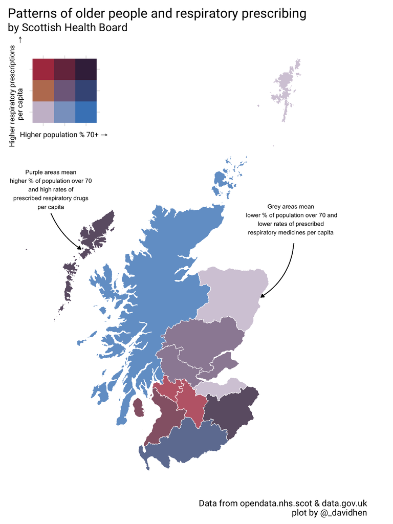

```r
final <-
  ggdraw()+
  draw_plot(map, 0,0,1,1)+
  draw_plot(key, 0.03,0.45,0.29,0.73)
final
```

## Save the output

```r
ggsave("age_resp_plot.png", final, width = 9, height = 12, dpi = 600)
```